# Red Wine Data Analysis

Information about dataset:

Citation Request:

This dataset is public available for research. The details are described in [Cortez et al., 2009]. Please include this citation if you plan to use this database:

P. Cortez, A. Cerdeira, F. Almeida, T. Matos and J. Reis. Modeling wine preferences by data mining from physicochemical properties. In Decision Support Systems, Elsevier, 47(4):547-553. ISSN: 0167-9236.

Available at: [@Elsevier] http://dx.doi.org/10.1016/j.dss.2009.05.016 [Pre-press (pdf)] http://www3.dsi.uminho.pt/pcortez/winequality09.pdf [bib] http://www3.dsi.uminho.pt/pcortez/dss09.bib

## 1. Title: Wine Quality

### 2. Sources

Created by: Paulo Cortez (Univ. Minho), Antonio Cerdeira, Fernando Almeida, Telmo Matos and Jose Reis (CVRVV) @ 2009

### 3. Past Usage:

P. Cortez, A. Cerdeira, F. Almeida, T. Matos and J. Reis. Modeling wine preferences by data mining from physicochemical properties. In Decision Support Systems, Elsevier, 47(4):547-553. ISSN: 0167-9236.

In the above reference, two datasets were created, using red and white wine samples. The inputs include objective tests (e.g. PH values) and the output is based on sensory data (median of at least 3 evaluations made by wine experts). Each expert graded the wine quality between 0 (very bad) and 10 (very excellent). Several data mining methods were applied to model these datasets under a regression approach. The support vector machine model achieved the best results. Several metrics were computed: MAD, confusion matrix for a fixed error tolerance (T), etc. Also, we plot the relative importances of the input variables (as measured by a sensitivity analysis procedure).

### 4. Relevant Information:

The two datasets are related to red and white variants of the Portuguese “Vinho Verde” wine. For more details, consult: http://www.vinhoverde.pt/en/ or the reference [Cortez et al., 2009]. Due to privacy and logistic issues, only physicochemical (inputs) and sensory (the output) variables are available (e.g. there is no data about grape types, wine brand, wine selling price, etc.).

These datasets can be viewed as classification or regression tasks. The classes are ordered and not balanced (e.g. there are munch more normal wines than excellent or poor ones). Outlier detection algorithms could be used to detect the few excellent or poor wines. Also, we are not sure if all input variables are relevant. So it could be interesting to test feature selection methods.

### 5. Number of Instances: red wine - 1599

### 6. Number of Attributes: 11 + output attribute

Note: several of the attributes may be correlated, thus it makes sense to apply some sort of feature selection.

### 7. Attribute information:

For more information, read [Cortez et al., 2009].

Input variables (based on physicochemical tests): 1 - fixed acidity (tartaric acid - g / dm^3) 2 - volatile acidity (acetic acid - g / dm^3) 3 - citric acid (g / dm^3) 4 - residual sugar (g / dm^3) 5 - chlorides (sodium chloride - g / dm^3 6 - free sulfur dioxide (mg / dm^3) 7 - total sulfur dioxide (mg / dm^3) 8 - density (g / cm^3) 9 - pH 10 - sulphates (potassium sulphate - g / dm3) 11 - alcohol (% by volume) Output variable (based on sensory data): 12 - quality (score between 0 and 10)

### 8. Missing Attribute Values: None

### 9. Description of attributes:

1 - fixed acidity: most acids involved with wine or fixed or nonvolatile (do not evaporate readily)

2 - volatile acidity: the amount of acetic acid in wine, which at too high of levels can lead to an unpleasant, vinegar taste

3 - citric acid: found in small quantities, citric acid can add ‘freshness’ and flavor to wines

4 - residual sugar: the amount of sugar remaining after fermentation stops, it’s rare to find wines with less than 1 gram/liter and wines with greater than 45 grams/liter are considered sweet

5 - chlorides: the amount of salt in the wine

6 - free sulfur dioxide: the free form of SO2 exists in equilibrium between molecular SO2 (as a dissolved gas) and bisulfite ion; it prevents microbial growth and the oxidation of wine

7 - total sulfur dioxide: amount of free and bound forms of S02; in low concentrations, SO2 is mostly undetectable in wine, but at free SO2 concentrations over 50 ppm, SO2 becomes evident in the nose and taste of wine

8 - density: the density of water is close to that of water depending on the percent alcohol and sugar content

9 - pH: describes how acidic or basic a wine is on a scale from 0 (very acidic) to 14 (very basic); most wines are between 3-4 on the pH scale

10 - sulphates: a wine additive which can contribute to sulfur dioxide gas (S02) levels, wich acts as an antimicrobial and antioxidant

11 - alcohol: the percent alcohol content of the wine

Output variable (based on sensory data): 12 - quality (score between 0 and 10)

### Loading Packages:

Loading packages where ggplot for plotting graph , plyr to group data, scales for log 10 , memisc for identify function in modelling and knitr to output rmarkdown to html.

### Loading Dataset:

Setting correct directory and loading ‘WineQualityReds.csv’ file in R

## Univariate Plots Section

Names of columns in datset

```
##  [1] "X"                    "fixed.acidity"        "volatile.acidity"
##  [4] "citric.acid"          "residual.sugar"       "chlorides"
##  [7] "free.sulfur.dioxide"  "total.sulfur.dioxide" "density"
## [10] "pH"                   "sulphates"            "alcohol"
## [13] "quality"
```

### Summary

```
##        X          fixed.acidity   volatile.acidity  citric.acid
##  Min.   :   1.0   Min.   : 4.60   Min.   :0.1200   Min.   :0.000
##  1st Qu.: 400.5   1st Qu.: 7.10   1st Qu.:0.3900   1st Qu.:0.090
##  Median : 800.0   Median : 7.90   Median :0.5200   Median :0.260
##  Mean   : 800.0   Mean   : 8.32   Mean   :0.5278   Mean   :0.271
##  3rd Qu.:1199.5   3rd Qu.: 9.20   3rd Qu.:0.6400   3rd Qu.:0.420
##  Max.   :1599.0   Max.   :15.90   Max.   :1.5800   Max.   :1.000
##  residual.sugar     chlorides       free.sulfur.dioxide
##  Min.   : 0.900   Min.   :0.01200   Min.   : 1.00
##  1st Qu.: 1.900   1st Qu.:0.07000   1st Qu.: 7.00
##  Median : 2.200   Median :0.07900   Median :14.00
##  Mean   : 2.539   Mean   :0.08747   Mean   :15.87
##  3rd Qu.: 2.600   3rd Qu.:0.09000   3rd Qu.:21.00
##  Max.   :15.500   Max.   :0.61100   Max.   :72.00
##  total.sulfur.dioxide    density             pH          sulphates
##  Min.   :  6.00       Min.   :0.9901   Min.   :2.740   Min.   :0.3300
##  1st Qu.: 22.00       1st Qu.:0.9956   1st Qu.:3.210   1st Qu.:0.5500
##  Median : 38.00       Median :0.9968   Median :3.310   Median :0.6200
##  Mean   : 46.47       Mean   :0.9967   Mean   :3.311   Mean   :0.6581
##  3rd Qu.: 62.00       3rd Qu.:0.9978   3rd Qu.:3.400   3rd Qu.:0.7300
##  Max.   :289.00       Max.   :1.0037   Max.   :4.010   Max.   :2.0000
##     alcohol         quality
##  Min.   : 8.40   Min.   :3.000
##  1st Qu.: 9.50   1st Qu.:5.000
##  Median :10.20   Median :6.000
##  Mean   :10.42   Mean   :5.636
##  3rd Qu.:11.10   3rd Qu.:6.000
##  Max.   :14.90   Max.   :8.000
```

##### Summary’s Obervation:

- There is big variation form minimum 0.9 to max 15.50 in Residual Sugar.
- Total Sulphate variation is very huge even from 3rd quartile 62.0 to maximum 289.
- pH value doesn’t vaires much as minimum is 2.7 to max 4.010, A pH level less than 7 is consider to be acidic so all wines in dataset are acidic. -Alcohol varies form 8.4% min to max 14.90% by volume.

### Dataset Dimension:

```
## [1] 1599   13
```

Dataset has 1599 obervation with 13 columns.

### Dataset structure:

```
## 'data.frame':    1599 obs. of  13 variables:
##  $ X                   : int  1 2 3 4 5 6 7 8 9 10 ...
##  $ fixed.acidity       : num  7.4 7.8 7.8 11.2 7.4 7.4 7.9 7.3 7.8 7.5 ...
##  $ volatile.acidity    : num  0.7 0.88 0.76 0.28 0.7 0.66 0.6 0.65 0.58 0.5 ...
##  $ citric.acid         : num  0 0 0.04 0.56 0 0 0.06 0 0.02 0.36 ...
##  $ residual.sugar      : num  1.9 2.6 2.3 1.9 1.9 1.8 1.6 1.2 2 6.1 ...
##  $ chlorides           : num  0.076 0.098 0.092 0.075 0.076 0.075 0.069 0.065 0.073 0.071 ...
##  $ free.sulfur.dioxide : num  11 25 15 17 11 13 15 15 9 17 ...
##  $ total.sulfur.dioxide: num  34 67 54 60 34 40 59 21 18 102 ...
##  $ density             : num  0.998 0.997 0.997 0.998 0.998 ...
##  $ pH                  : num  3.51 3.2 3.26 3.16 3.51 3.51 3.3 3.39 3.36 3.35 ...
##  $ sulphates           : num  0.56 0.68 0.65 0.58 0.56 0.56 0.46 0.47 0.57 0.8 ...
##  $ alcohol             : num  9.4 9.8 9.8 9.8 9.4 9.4 9.4 10 9.5 10.5 ...
##  $ quality             : int  5 5 5 6 5 5 5 7 7 5 ...
```

Dispalying compact structure of dataset with variable type and overview of values in variable columns.

Now in univariate I will explore individual variables and how can data distribution can be explained.

### Chlorides

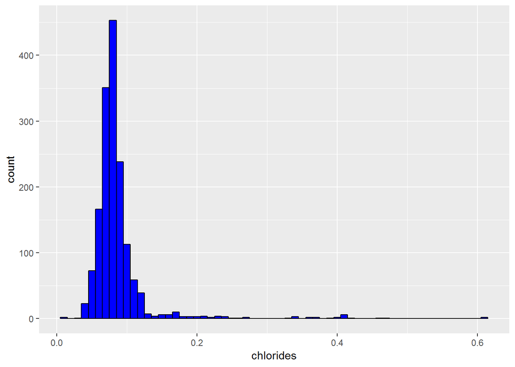

### Density

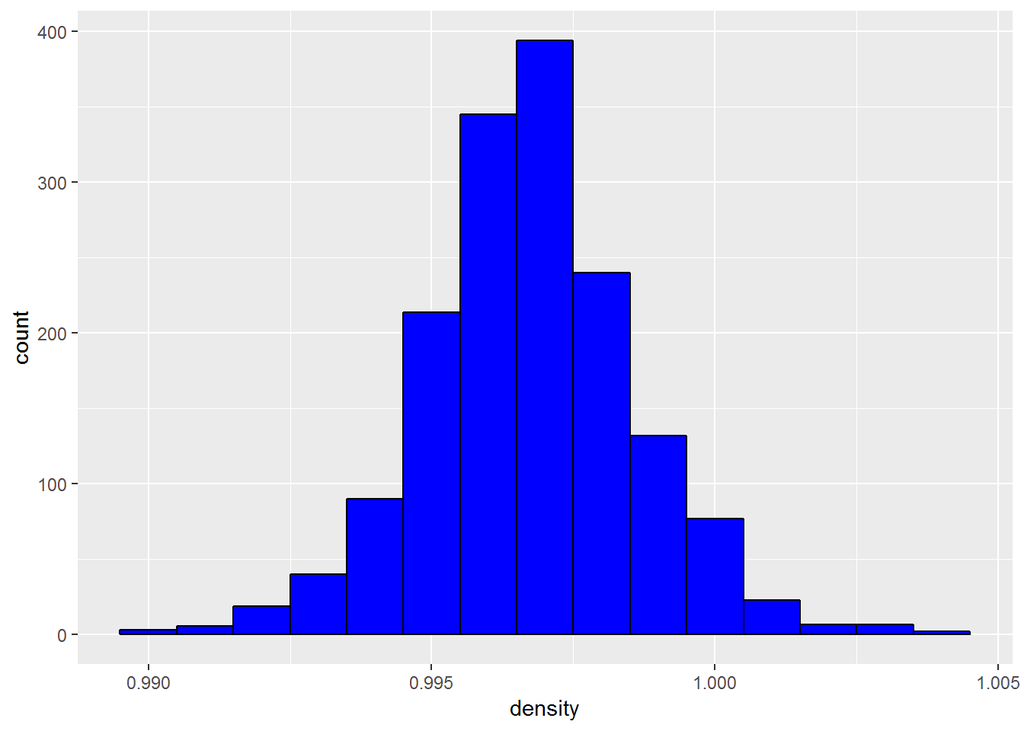

Density has perfect normal distribution histogram with no outliers.

### Residual Sugar

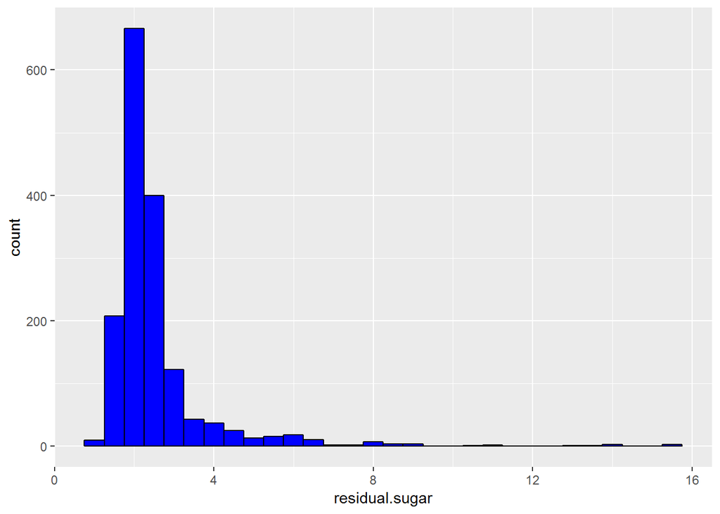

Residual sugar has positive skewed histrogram with long tail on right and quite few outliers.

### Quality

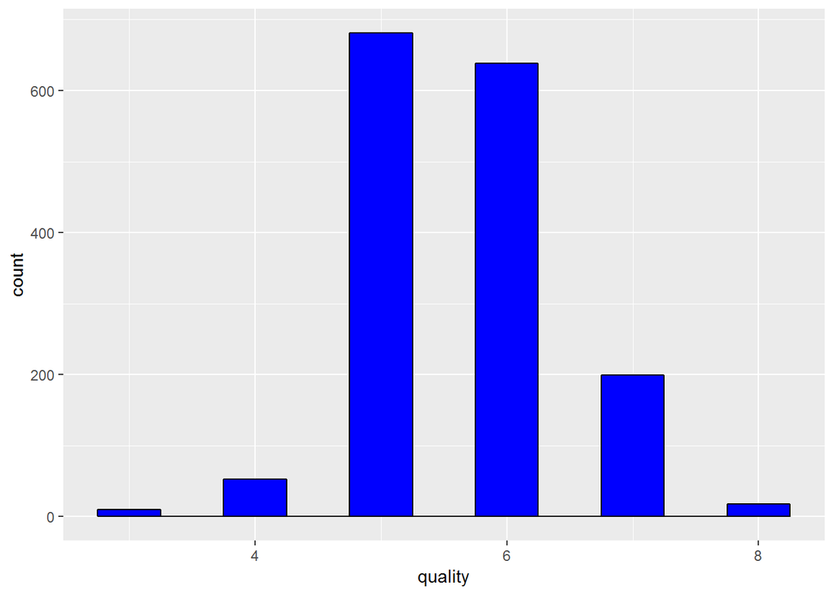

Histogram shows normal distribution with most wines are rated with quality rating 5/6 and only few are rated very low 3 or highest of 8.

### Acidity

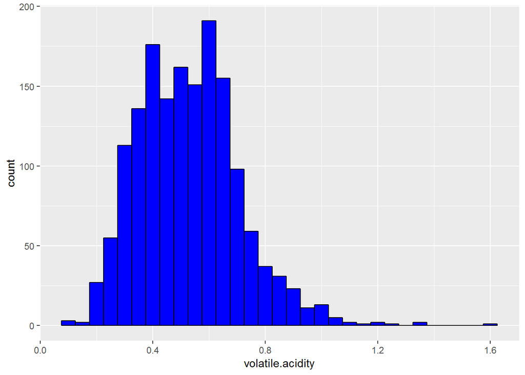

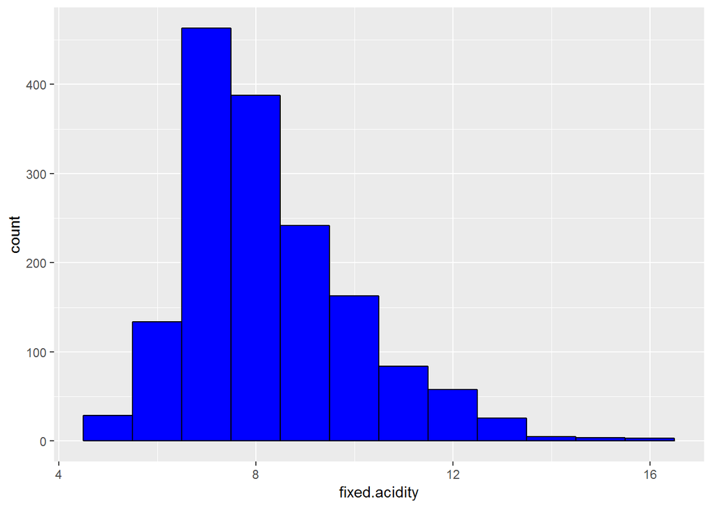

This shows Right or positive skewed histogram with longtail in positive direction.

### Sulphates

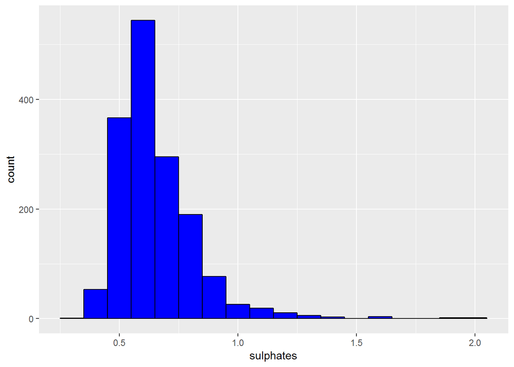

Sulphate has almost Normal distribution histogram with slight rightly skewed.

### Sulphur Dioxide

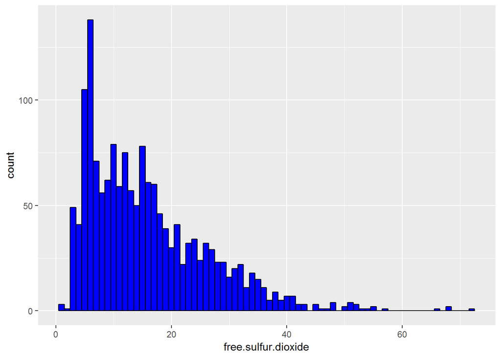

Right or positive skewed Hsitogram with few outliers above 60.

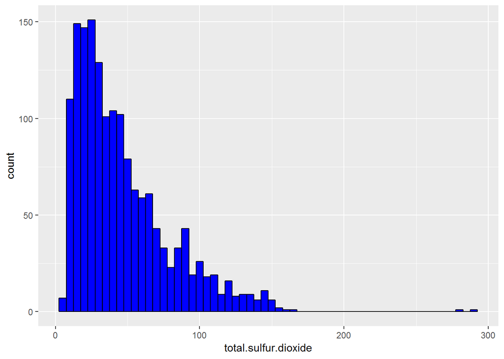

Right skewed with significant outlier.

### pH:

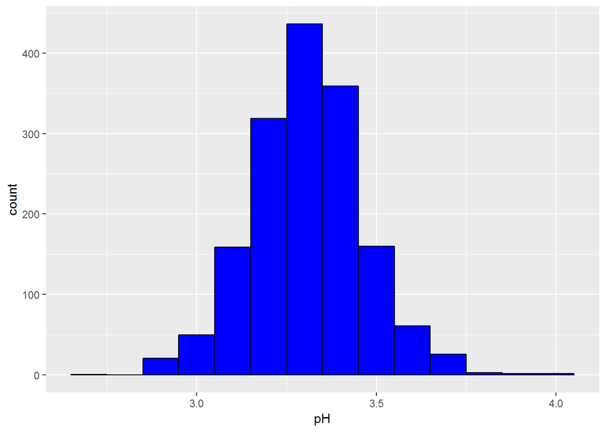

pH variable shows perfect histrogram.

### Alcohol:

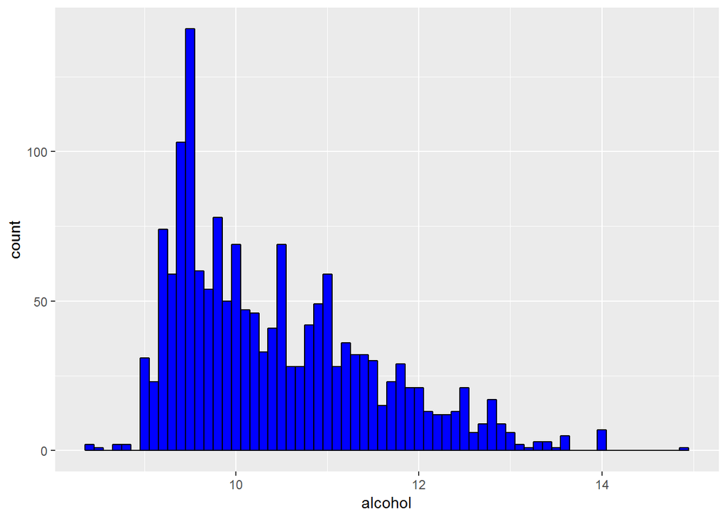

Alcohol shows right or positive skewed histrogram.

### Creating Quality Rating variable:

creating a catagorical variable ‘rating’ with quality to better undestand, as we can see from table below most of the wine fall in medium category , some in High and few in low

```
##
##    low medium   high
##     10   1372    217
```

## Univariate Analysis

#### What is the structure of your dataset?

Answer: Data set has 1599 rows and 14 columns

#### What is/are the main feature(s) of interest in your dataset?

Answer: I would like to focus on quality and its relationship with residual sugar.

#### What other features in the dataset do you think will help support your investigation into your feature(s) of interest?

Answer: Want to see if Alcohol, Density, PH and sulphates playing important role in quality.

### Of the features you investigated, were there any unusual distributions? Did you perform any operations on the data to tidy, adjust, or change the form of the data? If so, why did you do this?

Answer: No as data was tidy but has few outliers in some which I will remove in bivariate analysis

## Bivariate Plots Section

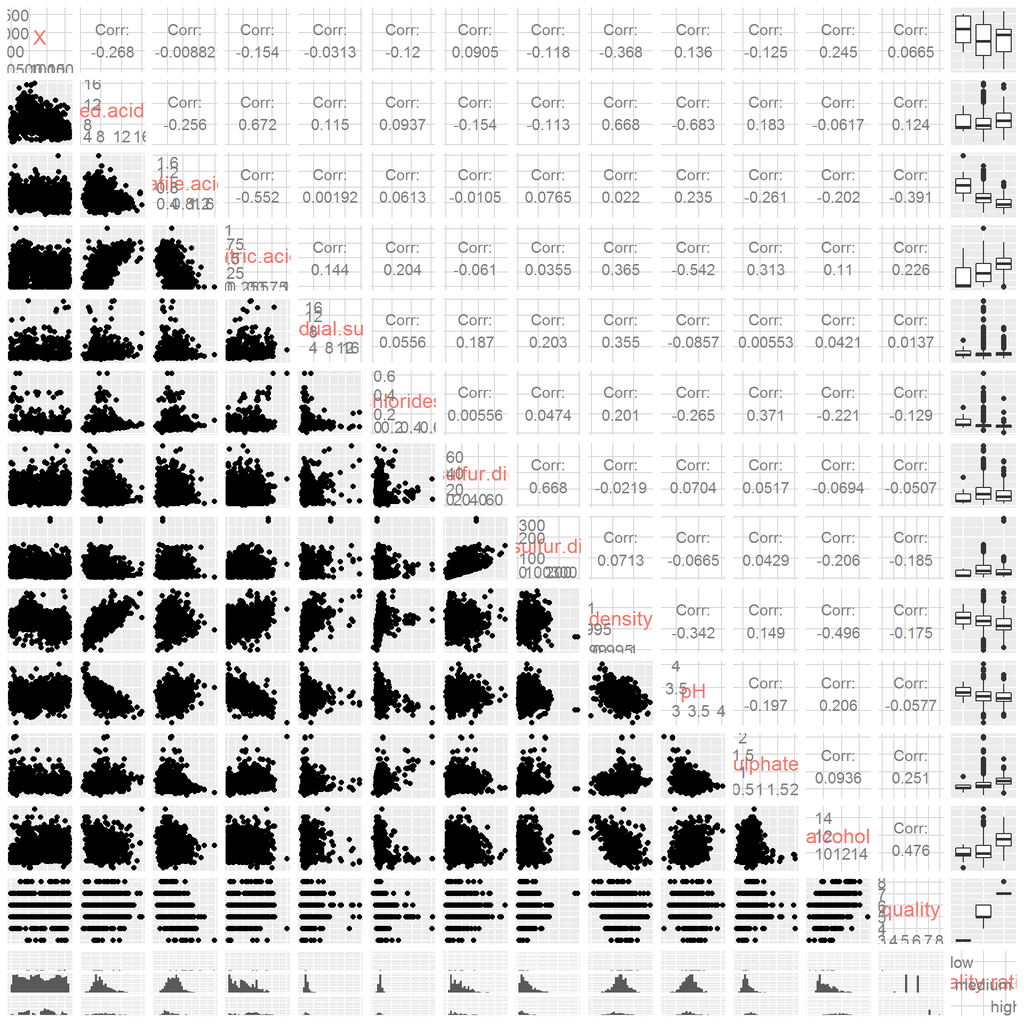

```
## $title
## [1] "Correlation between different variable in dataset"
##
## $subtitle
## NULL
##
## attr(,"class")
## [1] "labels"
```

As I am unable to find out which variables are more correlated with quality I will do correlation test with all other variable and then only investigate those which have near higher correlation values +1 or -1.

```
##              alcohol                   pH        fixed.acidity
##           0.47616632          -0.05773139           0.12405165
##     volatile.acidity          citric.acid       residual.sugar
##          -0.39055778           0.22637251           0.01373164
##            chlordies  free.sulfur.dioxide total.sulfur.dioxide
##          -0.12890656          -0.05065606          -0.18510029
##              density            sulphates
##          -0.17491923           0.25139708
```

From above correlation matrix I conclude that Alcohol and Sulphates two most positively correlated and volatile acidity and total sulphur dioxide are two most negatively correlated.

### Quality vs Residual Sugar:

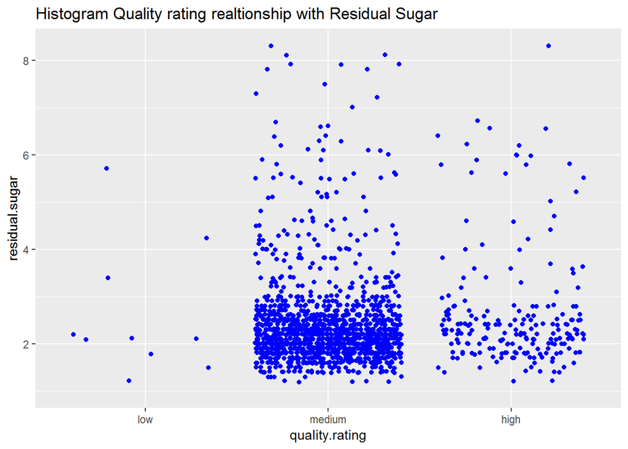

From above graph it clearly shows that most very few have low , most have medium and rest in high. In comparision with residual sugar most fall under 3

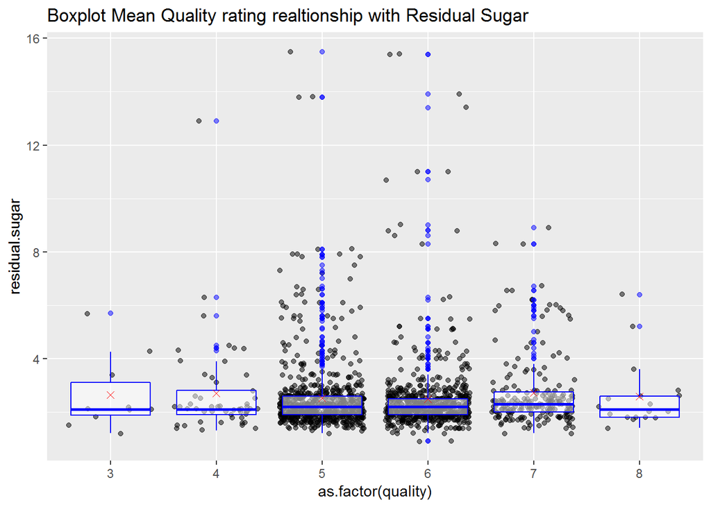

### Quality vs Alcohol:

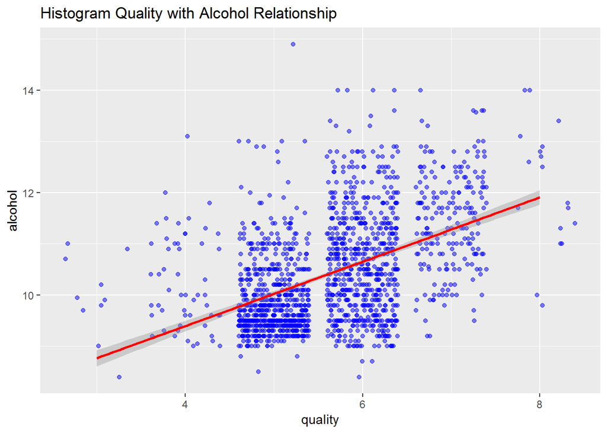

Plot above shows possible positive linear relationship between quality with alcohol.

### Quality vs pH:

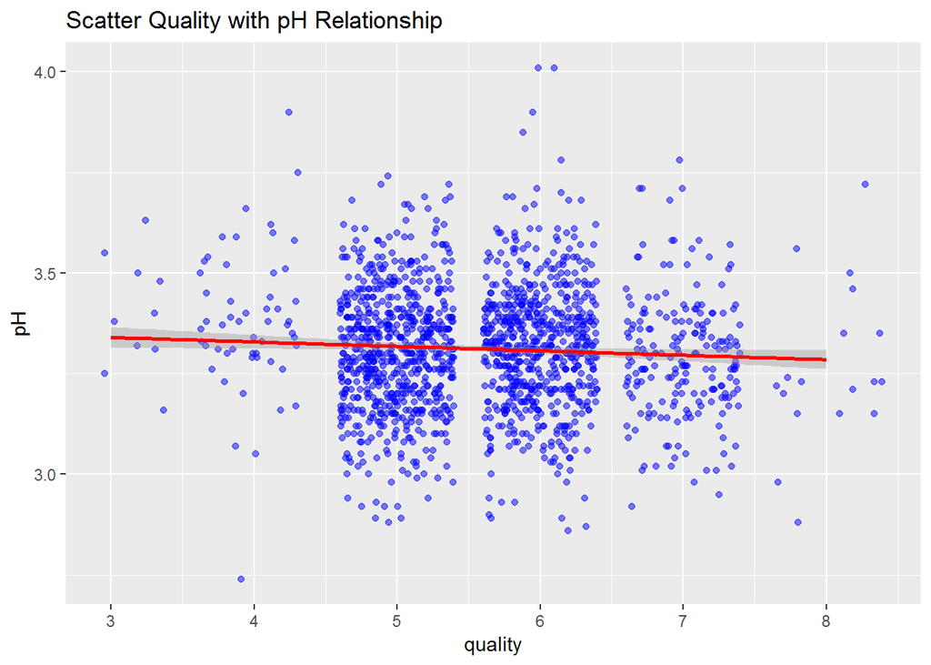

Almost staight horizontal line so pH don’t seems to have effect on quality.

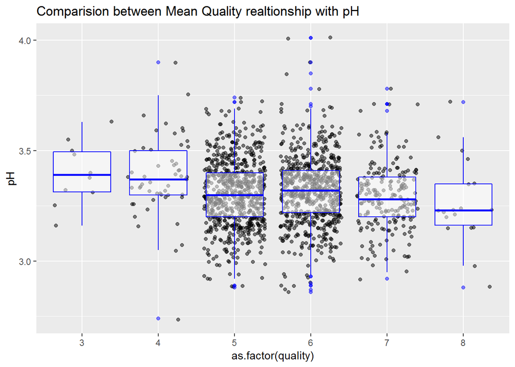

When I replot Quality with PH using Box plot and line across median points then negative relation can be seen so when Ph decreases or more acidic then quality is highest.

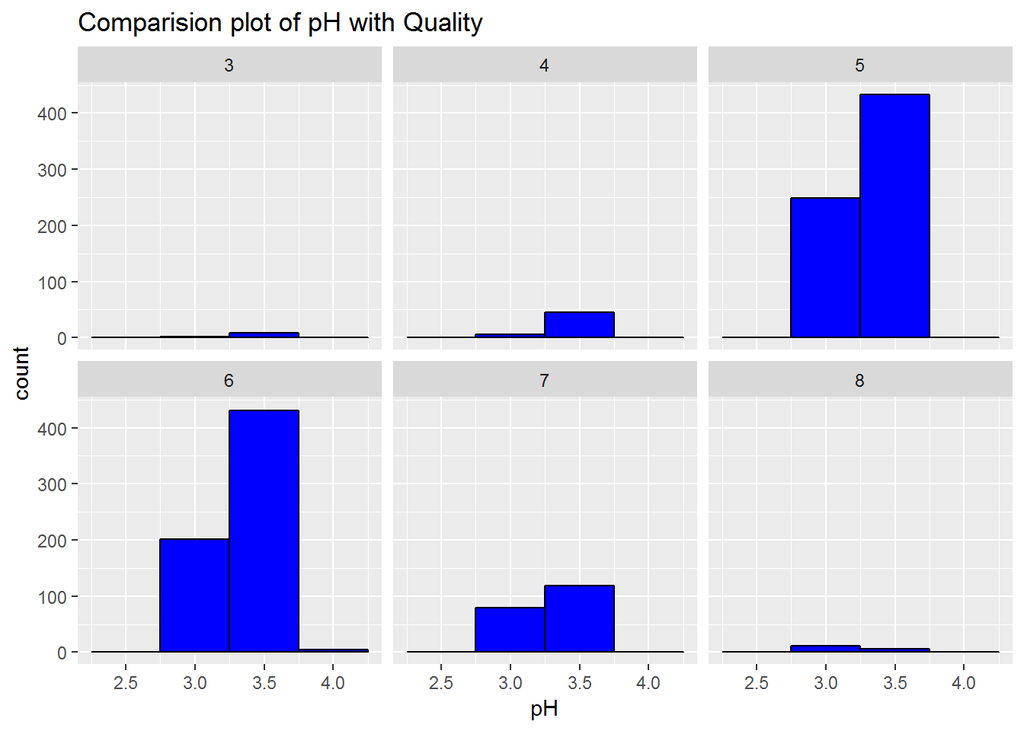

Almost same as plot before but confirm majority of wines has to stay with pH 2.75 to 3.75 so seems like regardless of quality ratings acidity level(pH) can’t be alter much.

### Quality vs Sulphates

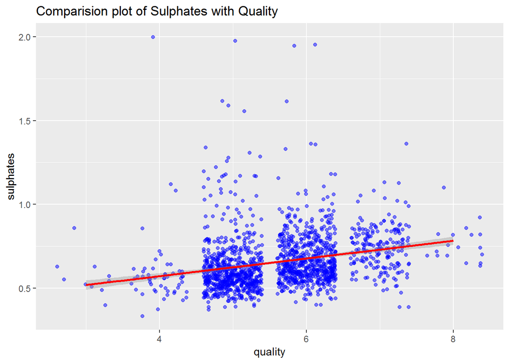

There is some positive relationship between sulphates and quality , I would guess approximately 0.25 in terms of ratio.

### Quality vs Density

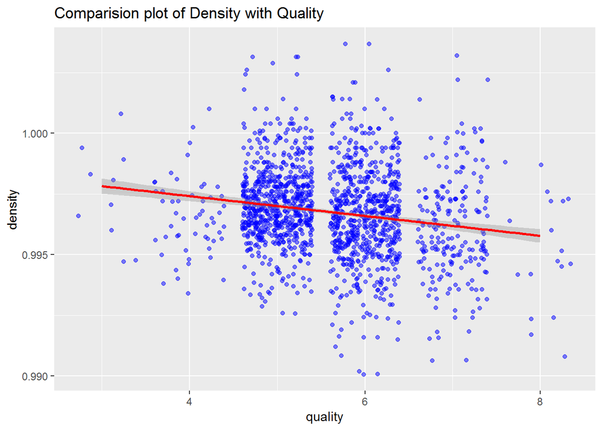

In above plot it shows tha quality tends to increase with decrease in density so inversely or negatively related variables.

### Quality vs Chlorides

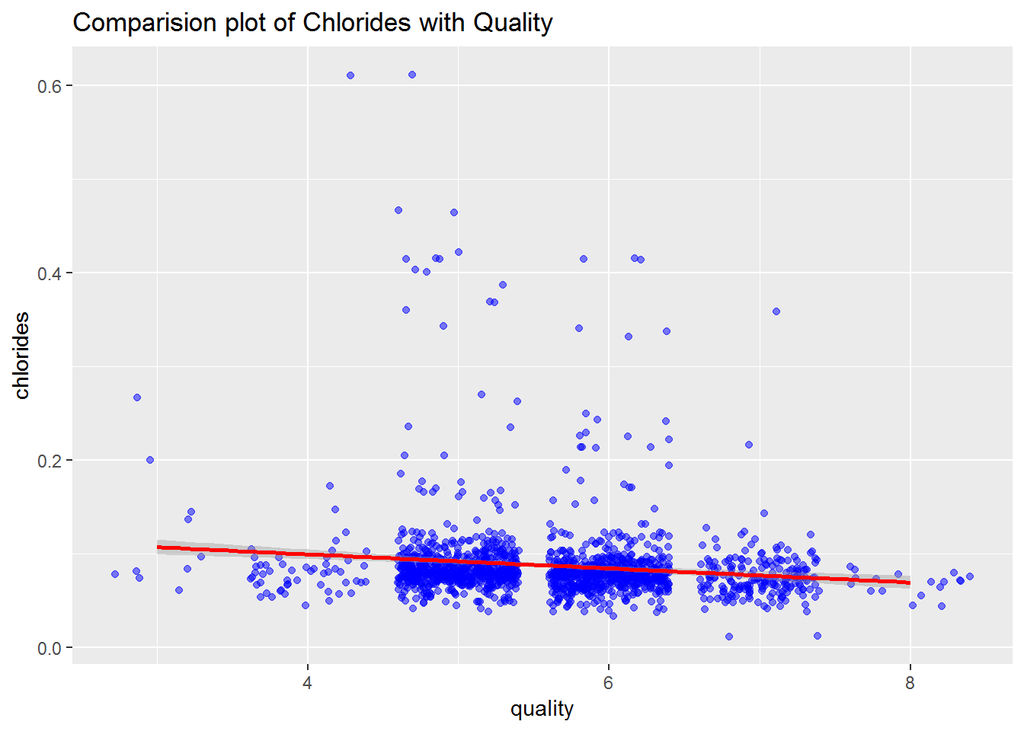

## Bivariate Analysis

#### Talk about some of the relationships you observed in this part of the investigation. How did the feature(s) of interest vary with other features in the dataset?

Answer: I explore quality with other vairables and found Sulphates and Alcohol have positive relationship , Residual Sugar don’t seems to effect on quality as it is maintained throughtout all quality ratings and lastly Density, pH and Chlorides seems to have negative relationship.

#### Did you observe any interesting relationships between the other features (not the main feature(s) of interest)?

Answer: In this given data set most wines have medium rating for 4.5-6.5 , only very few either very low 3 or very high 8.

## Multivariate Plots Section

In Multivariate section I have focused on two different variable correlations with Quality.

### Alcohol vs Sulphates

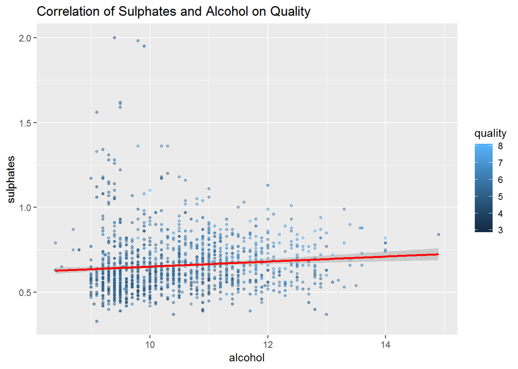

Sulphate content stays lower than 1 and quality increases with increase in Alcohol percentage by volume.

### Total Sulphur Dioxide vs Volatile Acidity

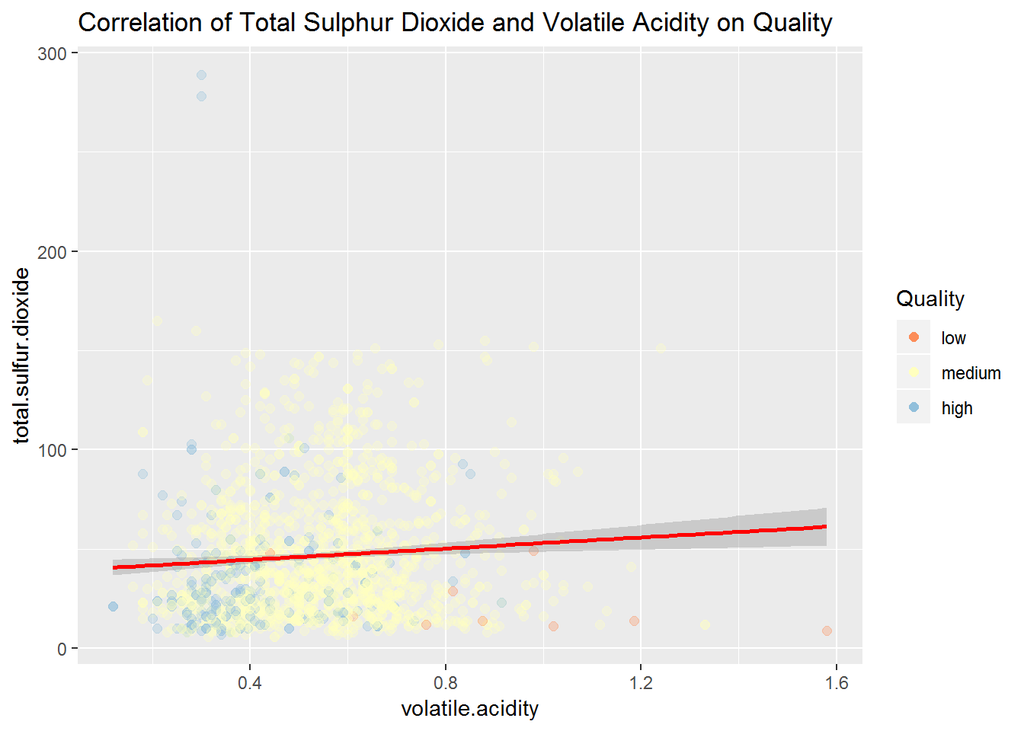

Highest Quality scores 7-8 have mostly less than 0.5 Volatile Acidity and 100 Total Sulfur Dioxide.

### pH vs Alcohol

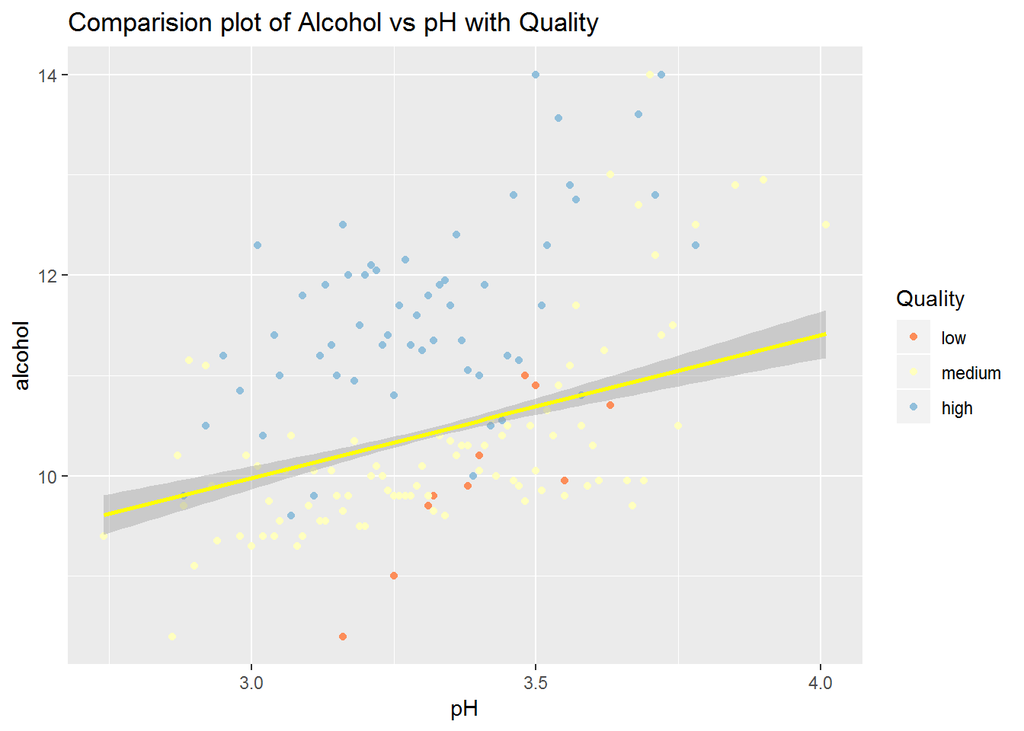

Wines with high Alcohol and low pH have highest quality rating 7 and 8.

### Citric Acid vs Fixed Acidity

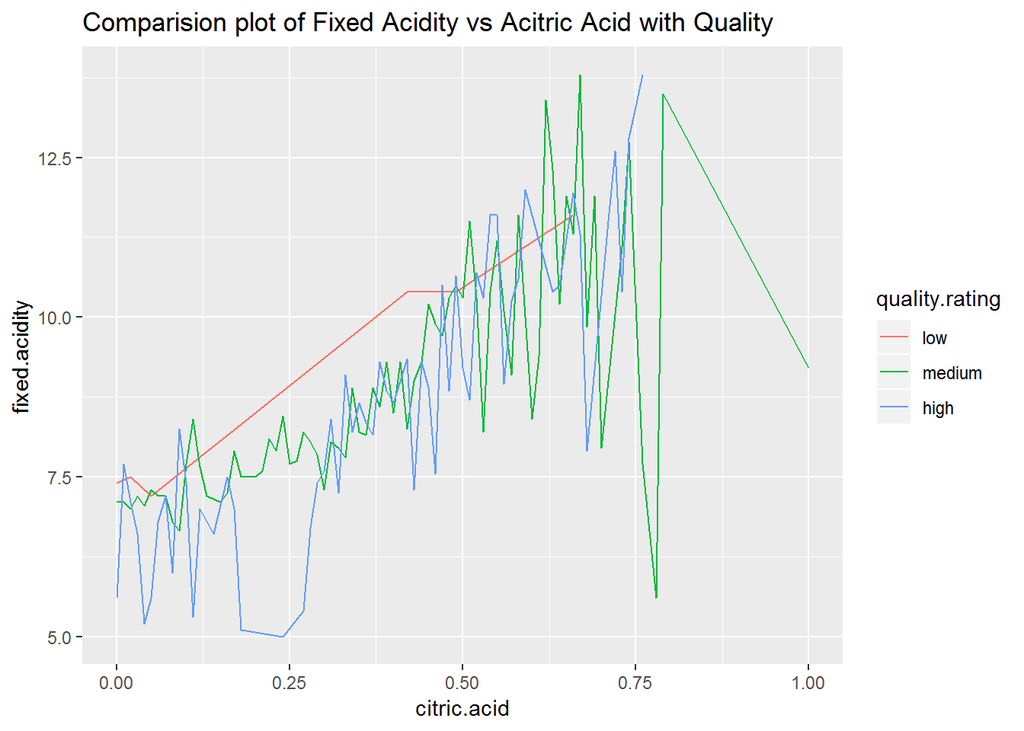

Fixed acidity and citric acid have positive relationship with quality.

### Alcohol vs Sulphates

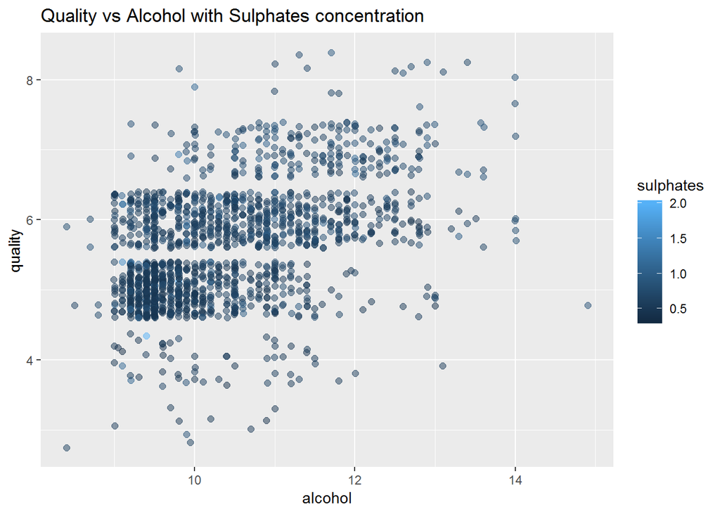

### Volatile Acidity vs Total Sulfur Dioxide

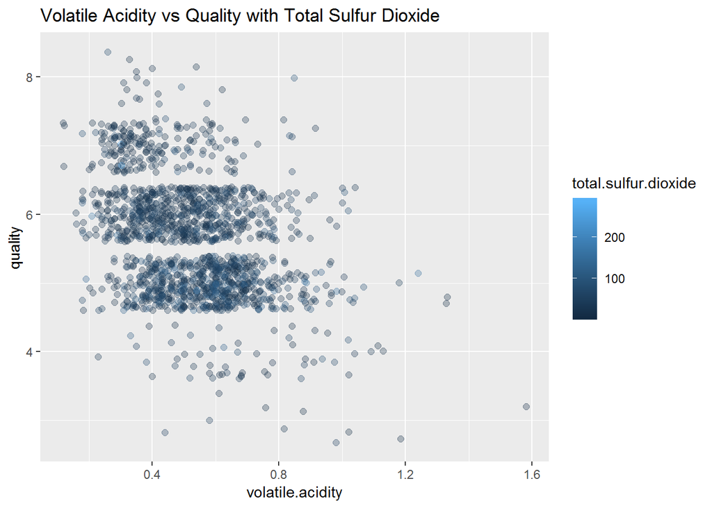

## Multivariate Analysis

### Talk about some of the relationships you observed in this part of the investigation. Were there features that strengthened each other in terms of looking at your feature(s) of interest?

Alcohol, citric acid , sulphate and volatile acidity really seems to impact quality and rest of variable also have some effect on quality but not very strong realtionship with quality.

### Were there any interesting or surprising interactions between features?

Citric Acid although in very small amount in wine but have real positive effect on quality

### OPTIONAL: Did you create any models with your dataset? Discuss the strengths and limitations of your model.

# Final Plots and Summary

## Plot One

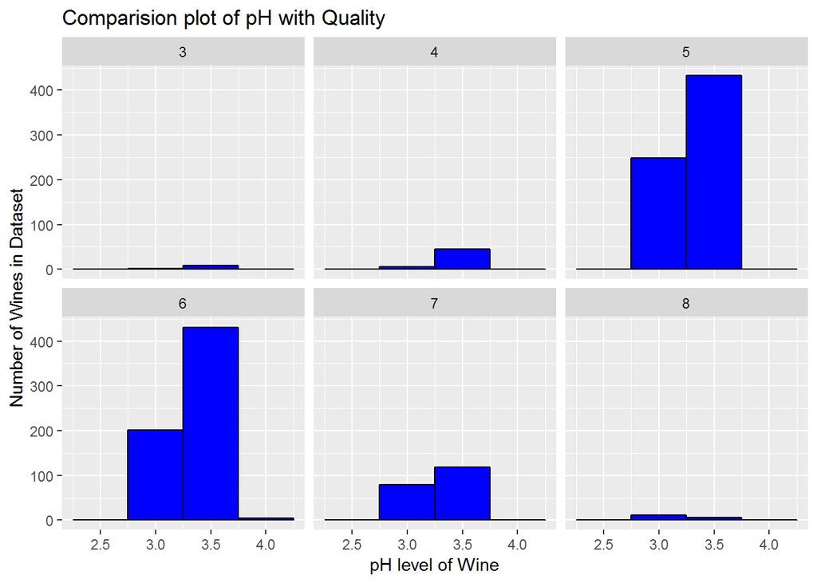

## Plot Two

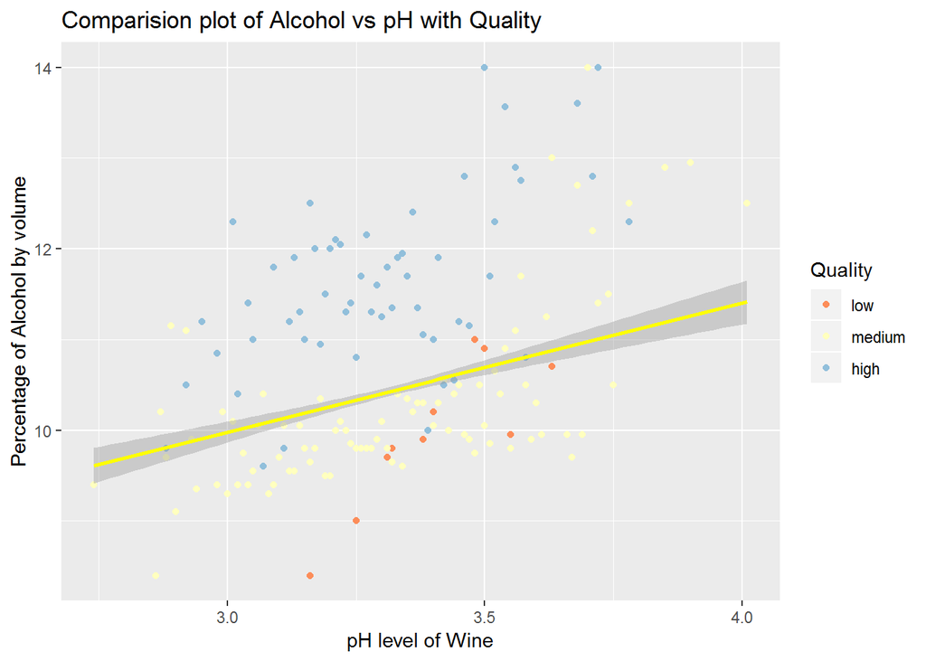

### Description Two

I choose this plot as until now I dont see any effect of pH on quality but when plot with alcohol I found that with increase in Alcohol volume and low pH it inrease quality level most.

## Plot Three

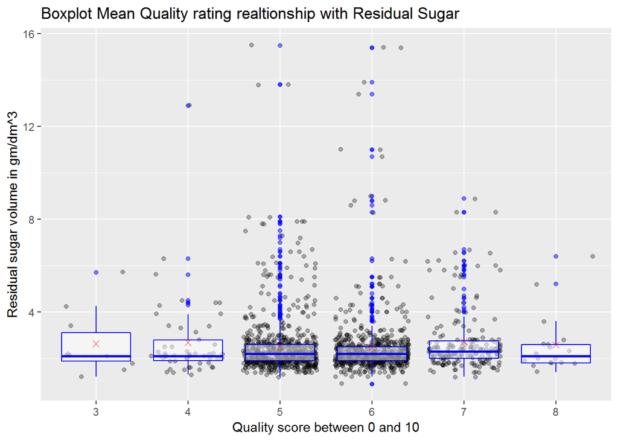

### Description Three

Residual sugar mean almost stay same on all quality level although their are some outliers with residual sugar level reaching up to 16.

# Reflection

I generally found R language not so easy to learn as seems like its missing flow , trying to plot what I head in mind mostly fails so I have to google with how people have done it , found Stackoverflow as usual most useful.Now when I have completed project I am thinkg R as not so difficult but need lot more practice and hopfully whenever I am able to switch career as Data Analyst I will be using it everyday.

I like working on this dataset as it give me taste that its is not always straight forward to find too many correlation with variable so plotting multiple variable give more insights. I beleive to get more better comparision best is to do Red and white wine comparison so it give more room for exploration.

# Refrences

http://www.sthda.com/english/wiki/correlation-test-between-two-variables-in-r https://www.rstudio.com/wp-content/uploads/2016/03/rmarkdown-cheatsheet-2.0.pdf https://udacitydatascience.slack.com/messages/C71BR5AP5/convo/C71BR5AP5-1535236620.000100/ https://www.google.co.uk/search?q=red+wine+dataset+in+r&ei=ACd_W8ieK8fQwQLvqryoAg&start=10&sa=N&biw=1536&bih=768&dpr=1.25 https://www.princeton.edu/~otorres/sessions/s2r.pdf